# C.E.A.P analysis

José Benardi de Souza Nunes

30/08/2018

# Introduction

> This exploratory data analysis was made based on data provided by the Brazilian government about the expenses allowed to its parliamentarians or C.E.A.P. (Cota para o Exercício da Atividade Parlamentar / Quota for the Exercise of Parliamentary Activity). More information about it (in Portuguese) can be found in its [official site](http://www2.camara.leg.br/transparencia/acesso-a-informacao/copy_of_perguntas-frequentes/cota-para-o-exercicio-da-atividade-parlamentar)

# Data Overview

```r
data <- read_csv(here::here("data/dadosCEAP.csv"),
                 progress = F,
                 col_types = cols(
                   nomeParlamentar = col_character(),
                   idCadastro = col_integer(),
                   sgUF = col_character(),
                   sgPartido = col_character(),
                   tipoDespesa = col_character(),
                   especDespesa = col_character(),
                   fornecedor = col_character(),
                   CNPJCPF = col_character(),
                   tipoDocumento = col_integer(),
                   dataEmissao = col_character(),
                   valorDocumento = col_double(),
                   valorGlosa = col_integer(),
                   valorLíquido = col_double()))
data %>%
  mutate(dataEmissao = parse_date_time(dataEmissao,"%Y-%m-%d %H:%M:%S"),
         year_month = paste(lubridate::year(dataEmissao),   # extract year
                            lubridate::month(dataEmissao),  # extract month
                            sep = "-"),
         tipoDespesa = toupper(tipoDespesa)) -> data
state_info <- read_csv(here::here("/data/limiteMensalCEAP.csv"),
                       progress = F,
                       col_types = cols(
                         UF = col_character(),
                         limite_mensal = col_double()))
data %>%
  full_join(state_info,
            by = c("sgUF" = "UF")) -> data
data %>%
  glimpse()
```

```
Observations: 963,452
Variables: 15
$ nomeParlamentar <chr> "ABEL MESQUITA JR.", "ABEL MESQUITA JR.", "ABEL MESQUITA JR.", "A...
$ idCadastro      <int> 178957, 178957, 178957, 178957, 178957, 178957, 178957, 178957, 1...
$ sgUF            <chr> "RR", "RR", "RR", "RR", "RR", "RR", "RR", "RR", "RR", "RR", "RR",...
$ sgPartido       <chr> "DEM", "DEM", "DEM", "DEM", "DEM", "DEM", "DEM", "DEM", "DEM", "D...
$ tipoDespesa     <chr> "MANUTENÇÃO DE ESCRITÓRIO DE APOIO À ATIVIDADE PARLAMENTAR", "MAN...
$ especDespesa    <chr> NA, NA, NA, NA, NA, "Veículos Automotores", "Veículos Automotores...
$ fornecedor      <chr> "COMPANHIA DE AGUAS E ESGOTOS DE RORAIMA", "COMPANHIA DE AGUAS E ...
$ CNPJCPF         <chr> "05939467000115", "05939467000115", "02341470000144", "0234147000...
$ tipoDocumento   <int> 0, 0, 0, 0, 0, 0, 0, 0, 0, 0, 0, 0, 0, 0, 0, 0, 0, 0, 0, 0, 0, 0,...
$ dataEmissao     <dttm> 2015-11-14, 2015-12-10, 2015-11-27, 2015-12-30, 2015-02-23, 2015...
$ valorDocumento  <dbl> 165.65, 59.48, 130.95, 196.53, 310.25, 32.00, 50.00, 50.00, 75.00...
$ valorGlosa      <int> 0, 0, 0, 347, 0, 0, 0, 0, 0, 0, 0, 0, 0, 0, 0, 0, 0, 0, 0, 0, 0, ...
$ valorLíquido    <dbl> 165.65, 59.48, 130.95, 193.06, 310.25, 32.00, 50.00, 50.00, 75.00...
$ year_month      <chr> "2015-11", "2015-12", "2015-11", "2015-12", "2015-2", "2015-6", "...
$ limite_mensal   <dbl> 45612.53, 45612.53, 45612.53, 45612.53, 45612.53, 45612.53, 45612...
```

```r
read_tsv(here::here("data/trsl_expenses.tsv"),
         progress = F,
         col_types = cols(
           original_term = col_character(),
           translation = col_character())) -> trsltd_expenses
trsltd_expenses
```

| original_term | translation |
| --- | --- |
| MANUTENÇÃO DE ESCRITÓRIO DE APOIO À ATIVIDADE PARLAMENTAR | MAINTENANCE OF OFFICE TO SUPPORT PARLIAMENTARY ACTIVITY |
| COMBUSTÍVEIS E LUBRIFICANTES. | FUELS AND LUBRICANTS. |
| CONSULTORIAS, PESQUISAS E TRABALHOS TÉCNICOS. | CONSULTANCIES, RESEARCH AND TECHNICAL WORKS. |
| DIVULGAÇÃO DA ATIVIDADE PARLAMENTAR. | DIVULGATION OF PARLIAMENTARY ACTIVITY. |
| SERVIÇO DE SEGURANÇA PRESTADO POR EMPRESA ESPECIALIZADA. | SECURITY SERVICE PROVIDED BY SPECIALIZED COMPANY. |
| PASSAGENS AÉREAS | AIRLINE TICKETS |
| SERVIÇOS POSTAIS | POSTAL SERVICES |
| FORNECIMENTO DE ALIMENTAÇÃO DO PARLAMENTAR | SUPPLY OF FOOD FOR PARLIAMENTARIAN |
| TELEFONIA | TELEPHONY |
| LOCAÇÃO OU FRETAMENTO DE VEÍCULOS AUTOMOTORES | LEASING OR FREIGHTING OF AUTOMOTIVE VEHICLES |

[output cut: 8 more lines]

- A translation for the description of each one of the 18 types of expense was recorded alongside its original term.

```r
data %>%
  full_join(trsltd_expenses,
            by = c("tipoDespesa" = "original_term"))  %>%
  mutate(tipoDespesa = translation) %>%  # translate col tipoDespesa
  select(-translation)-> data # drop unused column
data %>%
  sample_n(5) %>%
  select(nomeParlamentar,
         tipoDespesa,
         dataEmissao)
```

| nomeParlamentar | tipoDespesa | dataEmissao |
| --- | --- | --- |
| DELEGADO FRANCISCHINI | AIR TICKET ISSUANCE | 2016-06-16 |
| CELSO PANSERA | TELEPHONY | 2017-03-16 |
| VITOR LIPPI | TAXI SERVICE, TOLL AND PARKING | 2016-11-22 |
| ZÉ SILVA | AIR TICKET ISSUANCE | 2015-09-29 |
| PAULO PIMENTA | AIR TICKET ISSUANCE | 2015-04-17 |

- We now have each term in the column tipoDespesa translated.

```r
data %>%
  mutate(week_day = wday(dataEmissao),
         is_weekend = (week_day == 1) |
                         (week_day == 7)) -> data
data %>%
  select(dataEmissao,
         week_day,
         is_weekend) %>%
  sample_n(5)
```

| dataEmissao | week_day | is_weekend |
| --- | --- | --- |
| 2015-04-30 00:00:00 | 5 | FALSE |
| 2016-10-26 00:00:00 | 4 | FALSE |
| 2015-03-12 00:00:00 | 5 | FALSE |
| 2016-02-19 00:00:00 | 6 | FALSE |
| 2015-06-30 11:57:13 | 3 | FALSE |

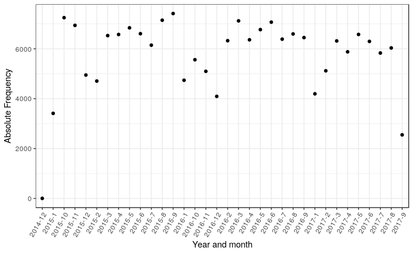

```r
data %>%
  na.omit(year_month) %>%
  group_by(year_month) %>%     # times used
  summarize(total = n()) %>%   # by year/month
  ggplot(aes(year_month, total)) +
  geom_point() +
  theme(axis.text.x = element_text(angle = 60,
                                   hjust = 1)) +
  labs(x="Year and month", y="Absolute Frequency")
```

- The period of time covered by the dataset is of about 3 years which amounts to the duration of our parliamentarian’s office minus the 120 days prior to the election.

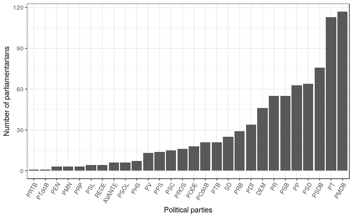

```r
data %>%
  group_by(idCadastro,
           nomeParlamentar) %>%
  slice(1) %>% # keep one entry for parliamentarian
  ungroup() %>%
  group_by(sgPartido) %>%              # calc parliamentarian
  summarize(num_parliament = n()) %>%  # by party
  na.omit() %>%
  ggplot(aes(reorder(sgPartido,
                     num_parliament),
             num_parliament)) +
  geom_bar(stat="identity") +
  labs(x="Political parties",
       y="Number of parliamentarians") +
  theme(axis.text.x = element_text(angle = 60,
                                   hjust = 1))
```

- We can see that **PMDB** detains the majority of offices followed closely by **PT** and that **PSDB** is still a major player. This was to be expected as the aforementioned parties are often regarded as the most proeminent ones in the Brazilian political scene.

# Expenditure during the week and the weekends

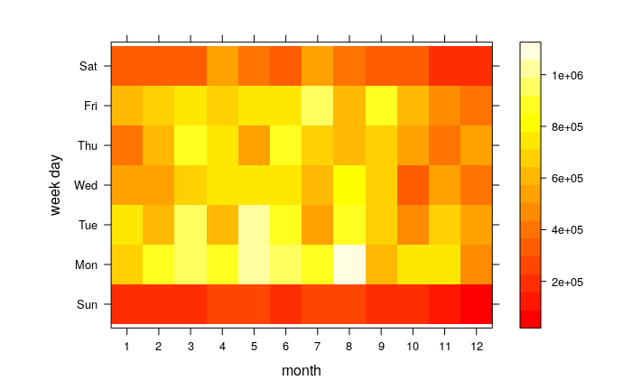

```r
data %>%
   mutate(month = lubridate::month(dataEmissao)) %>%  # extract month
  na.omit(week_day,month) %>%
  group_by(week_day,month) %>% # times used
  summarize(total = sum(valorLíquido)) %>%  # by day of week / month
  tidyr::spread(key= week_day, value=total,
                fill = 0) %>%
  select(-month) %>% data.matrix() -> matrix_yearly
colnames(matrix_yearly) <- c("Sun","Mon","Tue","Wed","Thu","Fri","Sat")
x.scale <- list(at=seq(from=1,to=12,by=1))
levelplot(matrix_yearly,
          col.regions=heat.colors,
          scales=list(x=x.scale),
          xlab="month", ylab= "week day")
```

- Overall we can see a clear predominace of expenditures during the week over those during the weekend.
  - It was to be expected, as CEAP is meant to be used to pay for work related expenses.

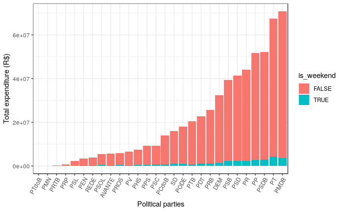

```r
data %>%
  group_by(is_weekend,sgPartido) %>%
  summarize(total_expense = sum(valorLíquido)) %>%
  na.omit(is_weekend) %>%
  ggplot(aes(reorder(sgPartido,
                     total_expense),
             total_expense,
             fill=is_weekend)) +
  geom_bar(stat="identity") +
  labs(x="Political parties",
       y="Total expenditure (R$)") +
  theme(axis.text.x = element_text(angle = 60,
                                   hjust = 1))
```

- Across diferent political parties the strong predominance of expenditures during the week holds.
  - PMDB is the biggest spender.
- **PMDB**, **PT** and **PSDB** are the parties with the highest number of offices, therefore it’s reasonable that they are the ones to spend the most.

## Which parties spent the most during the weekend?

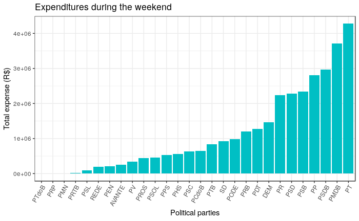

```r
data %>%
  filter(is_weekend) %>%
  group_by(is_weekend,sgPartido) %>%
  summarize(total_expense = sum(valorLíquido)) %>%
  na.omit(is_weekend) %>%
  ggplot(aes(reorder(sgPartido,
                     total_expense),
             total_expense)) +
  geom_bar(stat="identity",
           fill="#00BFC4") +
  labs(x="Political parties",
       y="Total expense (R$)",
       title="Expenditures during the weekend") +
  theme(axis.text.x = element_text(angle = 60,
                                   hjust = 1))
```

- **PMDB**, **PT** and **PSDB** are also the ones to spend the highest amount of money during the weekend.
- Despite the fact that overall **PMDB** is the biggest spender (as seen before) **PT** spent the most during the weekend.

## Which parties had most of their expenditures made during the weekend?

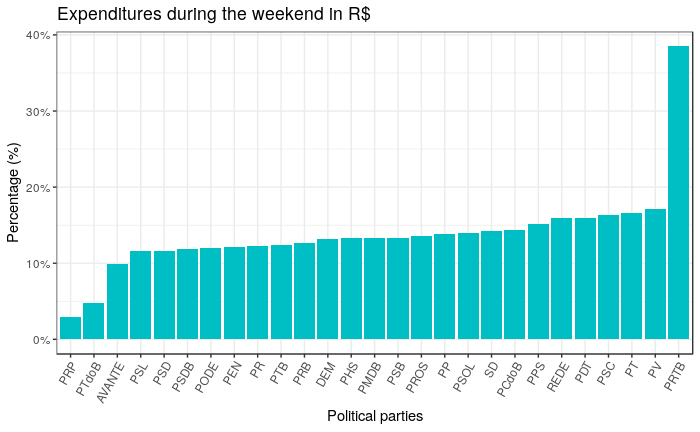

```r
data %>%
  na.omit(is_weekend,
          sgPartido) %>%
  group_by(sgPartido) %>%
  mutate(total = sum(valorLíquido)) %>%
  ungroup() %>%
  group_by(total,
           sgPartido,
           is_weekend) %>%
  summarize(total_expense = sum(valorLíquido)) %>%
  mutate(fract = total_expense/total) %>%
  filter(is_weekend) %>%
  ggplot(aes(reorder(sgPartido,fract),
             fract)) +
  geom_bar(stat="identity",
           fill="#00BFC4") +
    labs(x="Political parties",
       y="Percentage (%)",
       title="Expenditures during the weekend in R$") +
  scale_y_continuous(labels = scales::percent) +
  theme(axis.text.x = element_text(angle = 60,
                                   hjust = 1))
```

- Unexpectedly, we see as leader the party **PRTB** (ironically named Brazilian Labour Renewal Party) that made almost $40\%$ of its expenditures during the weekend.
- **PT** not only spent a great amount of money during the weekend as seen before, but had a substantial fraction of its expenditures made during the weekend.
- We can see that parties like **PV** and **PSC** which were obscured in terms of overall expense, stand out as some of the parties who spent a good part of their budget during the weekend.

# Looking at the cost of the suppliers

We will examine the top 10 most expensive suppliers (in terms of median cost).

```r
data %>%
  mutate(fornecedor = toupper(fornecedor)) %>%
  group_by(fornecedor, sgPartido) %>%              # calc expense of each
  summarize(total_expense = sum(valorLíquido)) %>% # supplier for each party
  ungroup() %>%
  group_by(fornecedor) %>%                           # calc median expense of
  mutate(median_expense = median(total_expense)) %>% # each supplier (all parties)
  ungroup() -> supplier_data
supplier_data %>%
  select(fornecedor,
         median_expense,
         sgPartido,
         total_expense) %>%
  sample_n(5)
```

| fornecedor | median_expense | sgPartido | total_expense |
| --- | --- | --- | --- |
| INDÚSTRIA E COMÉRCIO DE QUEIJOS SHJ LTDA. | 89.000 | PV | 39.00 |
| CLARO/SA NET | 900.795 | PDT | 1526.90 |
| POSTO DE GASOLINA MIDAS DA ALAMEDA LTDA ME | 179.440 | DEM | 179.44 |
| MT COMERCIO DE COMBUSTÍVEL LTDA | 110.000 | PHS | 18.89 |
| PARATY PETROLEO LTDA | 170.380 | PP | 228.07 |

- Now that we have the median cost of each supplier we can examine the overall behavior of the top 10 most expensive suppliers.

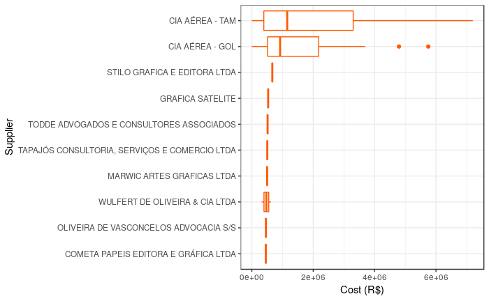